# Optimal Treatment Analysis

## Outcome Variable

**Outcome Variable:** ever_stunted

## Predictor Variables

**Intervention Variable:** hhwealth_quart

**Adjustment Set:**

- arm
- sex
- W_mage
- meducyrs
- feducyrs
- W_gagebrth
- W_birthwt
- W_birthlen
- W_nchldlt5
- W_parity
- delta_W_mage
- delta_meducyrs
- delta_feducyrs
- delta_W_gagebrth
- delta_W_birthwt
- delta_W_birthlen
- delta_W_nchldlt5
- delta_W_parity

## Stratifying Variables

The analysis was stratified on these variable(s):

- agecat
- studyid
- country

## Data Summary

| agecat | studyid | country | hhwealth_quart | ever_stunted | n_cell | n |
| --- | --- | --- | --- | --- | --- | --- |
| 0-24 months | ki0047075b-MAL-ED | BANGLADESH | Wealth Q4 | 0 | 7 | 82 |
| 0-24 months | ki0047075b-MAL-ED | BANGLADESH | Wealth Q4 | 1 | 14 | 82 |
| 0-24 months | ki0047075b-MAL-ED | BANGLADESH | Wealth Q1 | 0 | 6 | 82 |
| 0-24 months | ki0047075b-MAL-ED | BANGLADESH | Wealth Q1 | 1 | 15 | 82 |
| 0-24 months | ki0047075b-MAL-ED | BANGLADESH | Wealth Q2 | 0 | 8 | 82 |
| 0-24 months | ki0047075b-MAL-ED | BANGLADESH | Wealth Q2 | 1 | 12 | 82 |
| 0-24 months | ki0047075b-MAL-ED | BANGLADESH | Wealth Q3 | 0 | 8 | 82 |
| 0-24 months | ki0047075b-MAL-ED | BANGLADESH | Wealth Q3 | 1 | 12 | 82 |
| 0-24 months | ki0047075b-MAL-ED | INDIA | Wealth Q4 | 0 | 6 | 71 |
| 0-24 months | ki0047075b-MAL-ED | INDIA | Wealth Q4 | 1 | 12 | 71 |
| 0-24 months | ki0047075b-MAL-ED | INDIA | Wealth Q1 | 0 | 9 | 71 |
| 0-24 months | ki0047075b-MAL-ED | INDIA | Wealth Q1 | 1 | 10 | 71 |
| 0-24 months | ki0047075b-MAL-ED | INDIA | Wealth Q2 | 0 | 10 | 71 |
| 0-24 months | ki0047075b-MAL-ED | INDIA | Wealth Q2 | 1 | 7 | 71 |
| 0-24 months | ki0047075b-MAL-ED | INDIA | Wealth Q3 | 0 | 4 | 71 |
| 0-24 months | ki0047075b-MAL-ED | INDIA | Wealth Q3 | 1 | 13 | 71 |
| 0-24 months | ki0047075b-MAL-ED | NEPAL | Wealth Q4 | 0 | 4 | 42 |
| 0-24 months | ki0047075b-MAL-ED | NEPAL | Wealth Q4 | 1 | 7 | 42 |
| 0-24 months | ki0047075b-MAL-ED | NEPAL | Wealth Q1 | 0 | 6 | 42 |
| 0-24 months | ki0047075b-MAL-ED | NEPAL | Wealth Q1 | 1 | 5 | 42 |
| 0-24 months | ki0047075b-MAL-ED | NEPAL | Wealth Q2 | 0 | 4 | 42 |
| 0-24 months | ki0047075b-MAL-ED | NEPAL | Wealth Q2 | 1 | 6 | 42 |
| 0-24 months | ki0047075b-MAL-ED | NEPAL | Wealth Q3 | 0 | 6 | 42 |
| 0-24 months | ki0047075b-MAL-ED | NEPAL | Wealth Q3 | 1 | 4 | 42 |
| 0-24 months | ki0047075b-MAL-ED | PERU | Wealth Q4 | 0 | 2 | 37 |
| 0-24 months | ki0047075b-MAL-ED | PERU | Wealth Q4 | 1 | 8 | 37 |
| 0-24 months | ki0047075b-MAL-ED | PERU | Wealth Q1 | 0 | 2 | 37 |
| 0-24 months | ki0047075b-MAL-ED | PERU | Wealth Q1 | 1 | 7 | 37 |
| 0-24 months | ki0047075b-MAL-ED | PERU | Wealth Q2 | 0 | 0 | 37 |
| 0-24 months | ki0047075b-MAL-ED | PERU | Wealth Q2 | 1 | 9 | 37 |

[output cut: 378 more lines]

The following strata were considered:

- agecat: 0-24 months, studyid: ki0047075b-MAL-ED, country: BANGLADESH
- agecat: 0-24 months, studyid: ki0047075b-MAL-ED, country: INDIA
- agecat: 0-24 months, studyid: ki0047075b-MAL-ED, country: NEPAL
- agecat: 0-24 months, studyid: ki0047075b-MAL-ED, country: PERU
- agecat: 0-24 months, studyid: ki0047075b-MAL-ED, country: SOUTH AFRICA
- agecat: 0-24 months, studyid: ki0047075b-MAL-ED, country: TANZANIA, UNITED REPUBLIC OF
- agecat: 0-24 months, studyid: ki1000108-CMC-V-BCS-2002, country: INDIA
- agecat: 0-24 months, studyid: ki1000108-IRC, country: INDIA
- agecat: 0-24 months, studyid: ki1017093b-PROVIDE, country: BANGLADESH
- agecat: 0-24 months, studyid: ki1066203-TanzaniaChild2, country: TANZANIA, UNITED REPUBLIC OF
- agecat: 0-24 months, studyid: ki1113344-GMS-Nepal, country: NEPAL
- agecat: 0-24 months, studyid: ki1114097-CONTENT, country: PERU
- agecat: 0-24 months, studyid: ki1135781-COHORTS, country: GUATEMALA
- agecat: 0-24 months, studyid: ki1135781-COHORTS, country: PHILIPPINES
- agecat: 0-24 months, studyid: ki1148112-LCNI-5, country: MALAWI
- agecat: 0-24 months, studyid: kiGH5241-JiVitA-3, country: BANGLADESH
- agecat: 0-24 months, studyid: kiGH5241-JiVitA-4, country: BANGLADESH
- agecat: 0-6 months, studyid: ki0047075b-MAL-ED, country: BANGLADESH
- agecat: 0-6 months, studyid: ki0047075b-MAL-ED, country: INDIA
- agecat: 0-6 months, studyid: ki0047075b-MAL-ED, country: NEPAL
- agecat: 0-6 months, studyid: ki0047075b-MAL-ED, country: PERU
- agecat: 0-6 months, studyid: ki0047075b-MAL-ED, country: SOUTH AFRICA
- agecat: 0-6 months, studyid: ki0047075b-MAL-ED, country: TANZANIA, UNITED REPUBLIC OF
- agecat: 0-6 months, studyid: ki1000108-CMC-V-BCS-2002, country: INDIA
- agecat: 0-6 months, studyid: ki1000108-IRC, country: INDIA
- agecat: 0-6 months, studyid: ki1017093b-PROVIDE, country: BANGLADESH
- agecat: 0-6 months, studyid: ki1066203-TanzaniaChild2, country: TANZANIA, UNITED REPUBLIC OF
- agecat: 0-6 months, studyid: ki1113344-GMS-Nepal, country: NEPAL
- agecat: 0-6 months, studyid: ki1114097-CONTENT, country: PERU
- agecat: 0-6 months, studyid: ki1135781-COHORTS, country: GUATEMALA
- agecat: 0-6 months, studyid: ki1135781-COHORTS, country: PHILIPPINES
- agecat: 0-6 months, studyid: ki1148112-LCNI-5, country: MALAWI
- agecat: 0-6 months, studyid: kiGH5241-JiVitA-3, country: BANGLADESH
- agecat: 0-6 months, studyid: kiGH5241-JiVitA-4, country: BANGLADESH
- agecat: 6-24 months, studyid: ki0047075b-MAL-ED, country: BANGLADESH
- agecat: 6-24 months, studyid: ki0047075b-MAL-ED, country: INDIA
- agecat: 6-24 months, studyid: ki0047075b-MAL-ED, country: NEPAL
- agecat: 6-24 months, studyid: ki0047075b-MAL-ED, country: PERU
- agecat: 6-24 months, studyid: ki0047075b-MAL-ED, country: SOUTH AFRICA
- agecat: 6-24 months, studyid: ki0047075b-MAL-ED, country: TANZANIA, UNITED REPUBLIC OF
- agecat: 6-24 months, studyid: ki1000108-CMC-V-BCS-2002, country: INDIA
- agecat: 6-24 months, studyid: ki1000108-IRC, country: INDIA
- agecat: 6-24 months, studyid: ki1017093b-PROVIDE, country: BANGLADESH
- agecat: 6-24 months, studyid: ki1066203-TanzaniaChild2, country: TANZANIA, UNITED REPUBLIC OF
- agecat: 6-24 months, studyid: ki1113344-GMS-Nepal, country: NEPAL
- agecat: 6-24 months, studyid: ki1114097-CONTENT, country: PERU
- agecat: 6-24 months, studyid: ki1135781-COHORTS, country: GUATEMALA
- agecat: 6-24 months, studyid: ki1135781-COHORTS, country: PHILIPPINES
- agecat: 6-24 months, studyid: ki1148112-LCNI-5, country: MALAWI
- agecat: 6-24 months, studyid: kiGH5241-JiVitA-3, country: BANGLADESH
- agecat: 6-24 months, studyid: kiGH5241-JiVitA-4, country: BANGLADESH

### Dropped Strata

Some strata were dropped due to rare outcomes:

- agecat: 0-24 months, studyid: ki0047075b-MAL-ED, country: INDIA
- agecat: 0-24 months, studyid: ki0047075b-MAL-ED, country: NEPAL
- agecat: 0-24 months, studyid: ki0047075b-MAL-ED, country: PERU
- agecat: 0-24 months, studyid: ki0047075b-MAL-ED, country: TANZANIA, UNITED REPUBLIC OF
- agecat: 0-6 months, studyid: ki0047075b-MAL-ED, country: BANGLADESH
- agecat: 0-6 months, studyid: ki0047075b-MAL-ED, country: NEPAL
- agecat: 0-6 months, studyid: ki0047075b-MAL-ED, country: PERU
- agecat: 0-6 months, studyid: ki0047075b-MAL-ED, country: SOUTH AFRICA
- agecat: 0-6 months, studyid: ki0047075b-MAL-ED, country: TANZANIA, UNITED REPUBLIC OF
- agecat: 6-24 months, studyid: ki0047075b-MAL-ED, country: BANGLADESH
- agecat: 6-24 months, studyid: ki0047075b-MAL-ED, country: INDIA
- agecat: 6-24 months, studyid: ki0047075b-MAL-ED, country: NEPAL
- agecat: 6-24 months, studyid: ki0047075b-MAL-ED, country: PERU
- agecat: 6-24 months, studyid: ki0047075b-MAL-ED, country: SOUTH AFRICA
- agecat: 6-24 months, studyid: ki0047075b-MAL-ED, country: TANZANIA, UNITED REPUBLIC OF
- agecat: 6-24 months, studyid: ki1114097-CONTENT, country: PERU

## Methods Detail

We’re interested in the causal parameters $E[Y_a]$ for all values of $a \in \mathcal{A}$. These parameters represent the mean outcome if, possibly contrary to fact, we intervened to set all units to have $A=a$. Under the randomization and positivity assumptions, these are identified by the statistical parameters $\psi_a=E_W[E_{Y|A,W}(Y|A=a,W)]$. In addition, we’re interested in the mean of $Y$, $E[Y]$ under no intervention (the observed mean). We will estimate these parameters by using SuperLearner to fit the relevant likelihood factors – $E_{Y|A,W}(Y|A=a,W)$ and $p(A=a|W)$, and then updating our likelihood fit using a joint TMLE.

For unadjusted analyses ($W=\{\}$), initial likelihoods were estimated using Lrnr_glm to estimate the simple $E(Y|A)$ and Lrnr_mean to estimate $p(A)$. For adjusted analyses, a small library containing Lrnr_glmnet, Lrnr_xgboost, and Lrnr_mean was used.

Having estimated these parameters, we will then use the delta method to estimate relative risks and attributable risks relative to a prespecified baseline level of $A$.

# Results Detail

## Results Plots

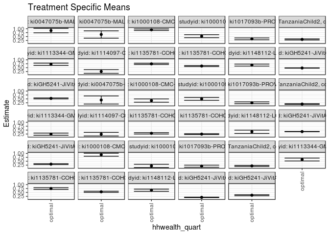

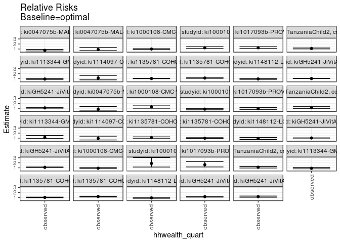

## Results Table

### Parameter: TSM

| agecat | studyid | country | intervention_level | baseline_level | estimate | ci_lower | ci_upper |
| --- | --- | --- | --- | --- | --- | --- | --- |
| 0-24 months | ki0047075b-MAL-ED | BANGLADESH | optimal | NA | 0.8812352 | 0.7362371 | 1.0262333 |
| 0-24 months | ki0047075b-MAL-ED | SOUTH AFRICA | optimal | NA | 0.6303930 | 0.3977082 | 0.8630777 |
| 0-24 months | ki1000108-CMC-V-BCS-2002 | INDIA | optimal | NA | 0.9332239 | 0.8824798 | 0.9839680 |
| 0-24 months | ki1000108-IRC | INDIA | optimal | NA | 0.5209692 | 0.4260864 | 0.6158519 |
| 0-24 months | ki1017093b-PROVIDE | BANGLADESH | optimal | NA | 0.3508601 | 0.2900146 | 0.4117057 |
| 0-24 months | ki1066203-TanzaniaChild2 | TANZANIA, UNITED REPUBLIC OF | optimal | NA | 0.3140105 | 0.2806680 | 0.3473530 |
| 0-24 months | ki1113344-GMS-Nepal | NEPAL | optimal | NA | 0.7229289 | 0.6487305 | 0.7971273 |
| 0-24 months | ki1114097-CONTENT | PERU | optimal | NA | 0.2588872 | 0.1432400 | 0.3745344 |
| 0-24 months | ki1135781-COHORTS | GUATEMALA | optimal | NA | 0.7464205 | 0.7061370 | 0.7867039 |
| 0-24 months | ki1135781-COHORTS | PHILIPPINES | optimal | NA | 0.6081200 | 0.5767186 | 0.6395214 |
| 0-24 months | ki1148112-LCNI-5 | MALAWI | optimal | NA | 0.6688899 | 0.6045899 | 0.7331899 |
| 0-24 months | kiGH5241-JiVitA-3 | BANGLADESH | optimal | NA | 0.4814698 | 0.4701513 | 0.4927883 |
| 0-24 months | kiGH5241-JiVitA-4 | BANGLADESH | optimal | NA | 0.5301455 | 0.4989782 | 0.5613129 |
| 0-6 months | ki0047075b-MAL-ED | INDIA | optimal | NA | 0.4295470 | 0.1708547 | 0.6882393 |
| 0-6 months | ki1000108-CMC-V-BCS-2002 | INDIA | optimal | NA | 0.3925431 | 0.2891759 | 0.4959103 |
| 0-6 months | ki1000108-IRC | INDIA | optimal | NA | 0.4999009 | 0.4065483 | 0.5932534 |
| 0-6 months | ki1017093b-PROVIDE | BANGLADESH | optimal | NA | 0.2486922 | 0.1899208 | 0.3074635 |
| 0-6 months | ki1066203-TanzaniaChild2 | TANZANIA, UNITED REPUBLIC OF | optimal | NA | 0.1692160 | 0.1399386 | 0.1984935 |
| 0-6 months | ki1113344-GMS-Nepal | NEPAL | optimal | NA | 0.2385135 | 0.1675620 | 0.3094649 |
| 0-6 months | ki1114097-CONTENT | PERU | optimal | NA | 0.2394820 | 0.1259545 | 0.3530094 |
| 0-6 months | ki1135781-COHORTS | GUATEMALA | optimal | NA | 0.2928887 | 0.2487084 | 0.3370690 |
| 0-6 months | ki1135781-COHORTS | PHILIPPINES | optimal | NA | 0.2427424 | 0.2164362 | 0.2690485 |
| 0-6 months | ki1148112-LCNI-5 | MALAWI | optimal | NA | 0.3918401 | 0.2846937 | 0.4989865 |
| 0-6 months | kiGH5241-JiVitA-3 | BANGLADESH | optimal | NA | 0.4018238 | 0.3917376 | 0.4119101 |
| 0-6 months | kiGH5241-JiVitA-4 | BANGLADESH | optimal | NA | 0.3159177 | 0.2907900 | 0.3410454 |
| 6-24 months | ki1000108-CMC-V-BCS-2002 | INDIA | optimal | NA | 0.9168044 | 0.8208019 | 1.0128069 |
| 6-24 months | ki1000108-IRC | INDIA | optimal | NA | 0.2010121 | 0.0956040 | 0.3064203 |
| 6-24 months | ki1017093b-PROVIDE | BANGLADESH | optimal | NA | 0.1841897 | 0.1183965 | 0.2499829 |
| 6-24 months | ki1066203-TanzaniaChild2 | TANZANIA, UNITED REPUBLIC OF | optimal | NA | 0.2031985 | 0.1679361 | 0.2384610 |
| 6-24 months | ki1113344-GMS-Nepal | NEPAL | optimal | NA | 0.6128352 | 0.5205582 | 0.7051123 |
| 6-24 months | ki1135781-COHORTS | GUATEMALA | optimal | NA | 0.7494301 | 0.6958178 | 0.8030424 |
| 6-24 months | ki1135781-COHORTS | PHILIPPINES | optimal | NA | 0.5405323 | 0.5025478 | 0.5785167 |
| 6-24 months | ki1148112-LCNI-5 | MALAWI | optimal | NA | 0.6404771 | 0.5706616 | 0.7102925 |
| 6-24 months | kiGH5241-JiVitA-3 | BANGLADESH | optimal | NA | 0.1856398 | 0.1709401 | 0.2003395 |
| 6-24 months | kiGH5241-JiVitA-4 | BANGLADESH | optimal | NA | 0.3225711 | 0.2882679 | 0.3568743 |

### Parameter: E(Y)

| agecat | studyid | country | intervention_level | baseline_level | estimate | ci_lower | ci_upper |
| --- | --- | --- | --- | --- | --- | --- | --- |
| 0-24 months | ki0047075b-MAL-ED | BANGLADESH | observed | NA | 0.6463415 | 0.5422228 | 0.7504601 |
| 0-24 months | ki0047075b-MAL-ED | SOUTH AFRICA | observed | NA | 0.5735294 | 0.4551072 | 0.6919516 |
| 0-24 months | ki1000108-CMC-V-BCS-2002 | INDIA | observed | NA | 0.9249330 | 0.8981563 | 0.9517096 |
| 0-24 months | ki1000108-IRC | INDIA | observed | NA | 0.6414634 | 0.5949863 | 0.6879405 |
| 0-24 months | ki1017093b-PROVIDE | BANGLADESH | observed | NA | 0.4340974 | 0.3973018 | 0.4708930 |
| 0-24 months | ki1066203-TanzaniaChild2 | TANZANIA, UNITED REPUBLIC OF | observed | NA | 0.3468960 | 0.3277853 | 0.3660067 |
| 0-24 months | ki1113344-GMS-Nepal | NEPAL | observed | NA | 0.6744186 | 0.6369554 | 0.7118819 |
| 0-24 months | ki1114097-CONTENT | PERU | observed | NA | 0.2930233 | 0.2320422 | 0.3540043 |
| 0-24 months | ki1135781-COHORTS | GUATEMALA | observed | NA | 0.7715180 | 0.7484902 | 0.7945458 |
| 0-24 months | ki1135781-COHORTS | PHILIPPINES | observed | NA | 0.6866209 | 0.6701747 | 0.7030670 |
| 0-24 months | ki1148112-LCNI-5 | MALAWI | observed | NA | 0.6376989 | 0.6047193 | 0.6706785 |
| 0-24 months | kiGH5241-JiVitA-3 | BANGLADESH | observed | NA | 0.4938998 | 0.4860534 | 0.5017461 |
| 0-24 months | kiGH5241-JiVitA-4 | BANGLADESH | observed | NA | 0.5818282 | 0.5658219 | 0.5978346 |
| 0-6 months | ki0047075b-MAL-ED | INDIA | observed | NA | 0.3521127 | 0.2402231 | 0.4640023 |
| 0-6 months | ki1000108-CMC-V-BCS-2002 | INDIA | observed | NA | 0.5108696 | 0.4597270 | 0.5620121 |
| 0-6 months | ki1000108-IRC | INDIA | observed | NA | 0.4243902 | 0.3764905 | 0.4722900 |
| 0-6 months | ki1017093b-PROVIDE | BANGLADESH | observed | NA | 0.2392550 | 0.2075826 | 0.2709275 |
| 0-6 months | ki1066203-TanzaniaChild2 | TANZANIA, UNITED REPUBLIC OF | observed | NA | 0.1950503 | 0.1791413 | 0.2109594 |
| 0-6 months | ki1113344-GMS-Nepal | NEPAL | observed | NA | 0.2774086 | 0.2416141 | 0.3132032 |
| 0-6 months | ki1114097-CONTENT | PERU | observed | NA | 0.2232558 | 0.1674626 | 0.2790491 |
| 0-6 months | ki1135781-COHORTS | GUATEMALA | observed | NA | 0.3240116 | 0.2955133 | 0.3525098 |
| 0-6 months | ki1135781-COHORTS | PHILIPPINES | observed | NA | 0.2391233 | 0.2240003 | 0.2542464 |
| 0-6 months | ki1148112-LCNI-5 | MALAWI | observed | NA | 0.3531599 | 0.2959376 | 0.4103821 |
| 0-6 months | kiGH5241-JiVitA-3 | BANGLADESH | observed | NA | 0.4108893 | 0.4034376 | 0.4183410 |
| 0-6 months | kiGH5241-JiVitA-4 | BANGLADESH | observed | NA | 0.3474692 | 0.3322601 | 0.3626783 |
| 6-24 months | ki1000108-CMC-V-BCS-2002 | INDIA | observed | NA | 0.8486486 | 0.7968646 | 0.9004327 |
| 6-24 months | ki1000108-IRC | INDIA | observed | NA | 0.3771186 | 0.3151523 | 0.4390850 |
| 6-24 months | ki1017093b-PROVIDE | BANGLADESH | observed | NA | 0.2989011 | 0.2567922 | 0.3410100 |
| 6-24 months | ki1066203-TanzaniaChild2 | TANZANIA, UNITED REPUBLIC OF | observed | NA | 0.2268170 | 0.2062654 | 0.2473687 |
| 6-24 months | ki1113344-GMS-Nepal | NEPAL | observed | NA | 0.5610329 | 0.5138522 | 0.6082135 |
| 6-24 months | ki1135781-COHORTS | GUATEMALA | observed | NA | 0.7665094 | 0.7380190 | 0.7949999 |
| 6-24 months | ki1135781-COHORTS | PHILIPPINES | observed | NA | 0.6449788 | 0.6246093 | 0.6653483 |
| 6-24 months | ki1148112-LCNI-5 | MALAWI | observed | NA | 0.6000000 | 0.5639396 | 0.6360604 |
| 6-24 months | kiGH5241-JiVitA-3 | BANGLADESH | observed | NA | 0.2172797 | 0.2079084 | 0.2266510 |
| 6-24 months | kiGH5241-JiVitA-4 | BANGLADESH | observed | NA | 0.3784303 | 0.3598372 | 0.3970234 |

### Parameter: RR

| agecat | studyid | country | intervention_level | baseline_level | estimate | ci_lower | ci_upper |
| --- | --- | --- | --- | --- | --- | --- | --- |
| 0-24 months | ki0047075b-MAL-ED | BANGLADESH | observed | optimal | 0.7334494 | 0.6054453 | 0.8885164 |
| 0-24 months | ki0047075b-MAL-ED | SOUTH AFRICA | observed | optimal | 0.9097967 | 0.6557085 | 1.2623445 |
| 0-24 months | ki1000108-CMC-V-BCS-2002 | INDIA | observed | optimal | 0.9911158 | 0.9443792 | 1.0401655 |
| 0-24 months | ki1000108-IRC | INDIA | observed | optimal | 1.2312887 | 1.0525608 | 1.4403650 |
| 0-24 months | ki1017093b-PROVIDE | BANGLADESH | observed | optimal | 1.2372377 | 1.0654556 | 1.4367162 |
| 0-24 months | ki1066203-TanzaniaChild2 | TANZANIA, UNITED REPUBLIC OF | observed | optimal | 1.1047274 | 1.0105141 | 1.2077245 |
| 0-24 months | ki1113344-GMS-Nepal | NEPAL | observed | optimal | 0.9328976 | 0.8529653 | 1.0203205 |
| 0-24 months | ki1114097-CONTENT | PERU | observed | optimal | 1.1318570 | 0.7732376 | 1.6568003 |
| 0-24 months | ki1135781-COHORTS | GUATEMALA | observed | optimal | 1.0336239 | 0.9913869 | 1.0776602 |
| 0-24 months | ki1135781-COHORTS | PHILIPPINES | observed | optimal | 1.1290877 | 1.0823041 | 1.1778936 |
| 0-24 months | ki1148112-LCNI-5 | MALAWI | observed | optimal | 0.9533690 | 0.8769868 | 1.0364038 |
| 0-24 months | kiGH5241-JiVitA-3 | BANGLADESH | observed | optimal | 1.0258166 | 1.0084831 | 1.0434482 |
| 0-24 months | kiGH5241-JiVitA-4 | BANGLADESH | observed | optimal | 1.0974878 | 1.0440356 | 1.1536766 |
| 0-6 months | ki0047075b-MAL-ED | INDIA | observed | optimal | 0.8197302 | 0.4940371 | 1.3601359 |
| 0-6 months | ki1000108-CMC-V-BCS-2002 | INDIA | observed | optimal | 1.3014357 | 1.0312405 | 1.6424247 |
| 0-6 months | ki1000108-IRC | INDIA | observed | optimal | 0.8489488 | 0.7240471 | 0.9953967 |
| 0-6 months | ki1017093b-PROVIDE | BANGLADESH | observed | optimal | 0.9620529 | 0.7932670 | 1.1667519 |
| 0-6 months | ki1066203-TanzaniaChild2 | TANZANIA, UNITED REPUBLIC OF | observed | optimal | 1.1526705 | 0.9925752 | 1.3385880 |
| 0-6 months | ki1113344-GMS-Nepal | NEPAL | observed | optimal | 1.1630733 | 0.8973862 | 1.5074218 |
| 0-6 months | ki1114097-CONTENT | PERU | observed | optimal | 0.9322448 | 0.6263061 | 1.3876288 |
| 0-6 months | ki1135781-COHORTS | GUATEMALA | observed | optimal | 1.1062619 | 0.9807535 | 1.2478318 |
| 0-6 months | ki1135781-COHORTS | PHILIPPINES | observed | optimal | 0.9850909 | 0.9014877 | 1.0764475 |
| 0-6 months | ki1148112-LCNI-5 | MALAWI | observed | optimal | 0.9012856 | 0.7117017 | 1.1413711 |
| 0-6 months | kiGH5241-JiVitA-3 | BANGLADESH | observed | optimal | 1.0225607 | 1.0046872 | 1.0407521 |
| 0-6 months | kiGH5241-JiVitA-4 | BANGLADESH | observed | optimal | 1.0998725 | 1.0323352 | 1.1718282 |
| 6-24 months | ki1000108-CMC-V-BCS-2002 | INDIA | observed | optimal | 0.9256594 | 0.8359542 | 1.0249909 |
| 6-24 months | ki1000108-IRC | INDIA | observed | optimal | 1.8760990 | 1.1603654 | 3.0333095 |
| 6-24 months | ki1017093b-PROVIDE | BANGLADESH | observed | optimal | 1.6227894 | 1.1776904 | 2.2361101 |
| 6-24 months | ki1066203-TanzaniaChild2 | TANZANIA, UNITED REPUBLIC OF | observed | optimal | 1.1162337 | 0.9641555 | 1.2922995 |
| 6-24 months | ki1113344-GMS-Nepal | NEPAL | observed | optimal | 0.9154710 | 0.8020635 | 1.0449138 |
| 6-24 months | ki1135781-COHORTS | GUATEMALA | observed | optimal | 1.0227898 | 0.9652199 | 1.0837934 |
| 6-24 months | ki1135781-COHORTS | PHILIPPINES | observed | optimal | 1.1932290 | 1.1261130 | 1.2643451 |
| 6-24 months | ki1148112-LCNI-5 | MALAWI | observed | optimal | 0.9368017 | 0.8528178 | 1.0290562 |
| 6-24 months | kiGH5241-JiVitA-3 | BANGLADESH | observed | optimal | 1.1704372 | 1.0942589 | 1.2519188 |
| 6-24 months | kiGH5241-JiVitA-4 | BANGLADESH | observed | optimal | 1.1731687 | 1.0680385 | 1.2886472 |

### Parameter: PAR

| agecat | studyid | country | intervention_level | baseline_level | estimate | ci_lower | ci_upper |
| --- | --- | --- | --- | --- | --- | --- | --- |
| 0-24 months | ki0047075b-MAL-ED | BANGLADESH | optimal | NA | -0.2348937 | -0.3852811 | -0.0845064 |
| 0-24 months | ki0047075b-MAL-ED | SOUTH AFRICA | optimal | NA | -0.0568635 | -0.2624673 | 0.1487403 |
| 0-24 months | ki1000108-CMC-V-BCS-2002 | INDIA | optimal | NA | -0.0082909 | -0.0533513 | 0.0367694 |
| 0-24 months | ki1000108-IRC | INDIA | optimal | NA | 0.1204943 | 0.0396022 | 0.2013863 |
| 0-24 months | ki1017093b-PROVIDE | BANGLADESH | optimal | NA | 0.0832373 | 0.0304693 | 0.1360052 |
| 0-24 months | ki1066203-TanzaniaChild2 | TANZANIA, UNITED REPUBLIC OF | optimal | NA | 0.0328855 | 0.0048904 | 0.0608806 |
| 0-24 months | ki1113344-GMS-Nepal | NEPAL | optimal | NA | -0.0485103 | -0.1131679 | 0.0161474 |
| 0-24 months | ki1114097-CONTENT | PERU | optimal | NA | 0.0341361 | -0.0642676 | 0.1325397 |
| 0-24 months | ki1135781-COHORTS | GUATEMALA | optimal | NA | 0.0250975 | -0.0059685 | 0.0561636 |
| 0-24 months | ki1135781-COHORTS | PHILIPPINES | optimal | NA | 0.0785008 | 0.0529787 | 0.1040230 |
| 0-24 months | ki1148112-LCNI-5 | MALAWI | optimal | NA | -0.0311910 | -0.0869972 | 0.0246152 |
| 0-24 months | kiGH5241-JiVitA-3 | BANGLADESH | optimal | NA | 0.0124299 | 0.0042261 | 0.0206338 |
| 0-24 months | kiGH5241-JiVitA-4 | BANGLADESH | optimal | NA | 0.0516827 | 0.0252812 | 0.0780842 |
| 0-6 months | ki0047075b-MAL-ED | INDIA | optimal | NA | -0.0774343 | -0.2967328 | 0.1418641 |
| 0-6 months | ki1000108-CMC-V-BCS-2002 | INDIA | optimal | NA | 0.1183265 | 0.0275269 | 0.2091261 |
| 0-6 months | ki1000108-IRC | INDIA | optimal | NA | -0.0755106 | -0.1547645 | 0.0037433 |
| 0-6 months | ki1017093b-PROVIDE | BANGLADESH | optimal | NA | -0.0094371 | -0.0574556 | 0.0385813 |
| 0-6 months | ki1066203-TanzaniaChild2 | TANZANIA, UNITED REPUBLIC OF | optimal | NA | 0.0258343 | 0.0005227 | 0.0511459 |
| 0-6 months | ki1113344-GMS-Nepal | NEPAL | optimal | NA | 0.0388952 | -0.0228192 | 0.1006095 |
| 0-6 months | ki1114097-CONTENT | PERU | optimal | NA | -0.0162262 | -0.1116507 | 0.0791983 |
| 0-6 months | ki1135781-COHORTS | GUATEMALA | optimal | NA | 0.0311229 | -0.0041864 | 0.0664323 |
| 0-6 months | ki1135781-COHORTS | PHILIPPINES | optimal | NA | -0.0036191 | -0.0251460 | 0.0179079 |
| 0-6 months | ki1148112-LCNI-5 | MALAWI | optimal | NA | -0.0386802 | -0.1308358 | 0.0534753 |
| 0-6 months | kiGH5241-JiVitA-3 | BANGLADESH | optimal | NA | 0.0090654 | 0.0019754 | 0.0161555 |
| 0-6 months | kiGH5241-JiVitA-4 | BANGLADESH | optimal | NA | 0.0315515 | 0.0115822 | 0.0515208 |
| 6-24 months | ki1000108-CMC-V-BCS-2002 | INDIA | optimal | NA | -0.0681558 | -0.1606429 | 0.0243314 |
| 6-24 months | ki1000108-IRC | INDIA | optimal | NA | 0.1761065 | 0.0783419 | 0.2738712 |
| 6-24 months | ki1017093b-PROVIDE | BANGLADESH | optimal | NA | 0.1147114 | 0.0543538 | 0.1750690 |
| 6-24 months | ki1066203-TanzaniaChild2 | TANZANIA, UNITED REPUBLIC OF | optimal | NA | 0.0236185 | -0.0061829 | 0.0534199 |
| 6-24 months | ki1113344-GMS-Nepal | NEPAL | optimal | NA | -0.0518023 | -0.1325969 | 0.0289922 |
| 6-24 months | ki1135781-COHORTS | GUATEMALA | optimal | NA | 0.0170794 | -0.0262862 | 0.0604449 |
| 6-24 months | ki1135781-COHORTS | PHILIPPINES | optimal | NA | 0.1044465 | 0.0735144 | 0.1353787 |
| 6-24 months | ki1148112-LCNI-5 | MALAWI | optimal | NA | -0.0404771 | -0.1005646 | 0.0196104 |
| 6-24 months | kiGH5241-JiVitA-3 | BANGLADESH | optimal | NA | 0.0316399 | 0.0190442 | 0.0442357 |
| 6-24 months | kiGH5241-JiVitA-4 | BANGLADESH | optimal | NA | 0.0558592 | 0.0254745 | 0.0862439 |

### Parameter: PAF

| agecat | studyid | country | intervention_level | baseline_level | estimate | ci_lower | ci_upper |
| --- | --- | --- | --- | --- | --- | --- | --- |
| 0-24 months | ki0047075b-MAL-ED | BANGLADESH | optimal | NA | -0.3634205 | -0.6516768 | -0.1254717 |
| 0-24 months | ki0047075b-MAL-ED | SOUTH AFRICA | optimal | NA | -0.0991467 | -0.5250680 | 0.2078232 |
| 0-24 months | ki1000108-CMC-V-BCS-2002 | INDIA | optimal | NA | -0.0089638 | -0.0588967 | 0.0386145 |
| 0-24 months | ki1000108-IRC | INDIA | optimal | NA | 0.1878428 | 0.0499361 | 0.3057315 |
| 0-24 months | ki1017093b-PROVIDE | BANGLADESH | optimal | NA | 0.1917479 | 0.0614344 | 0.3039683 |
| 0-24 months | ki1066203-TanzaniaChild2 | TANZANIA, UNITED REPUBLIC OF | optimal | NA | 0.0947993 | 0.0104047 | 0.1719966 |
| 0-24 months | ki1113344-GMS-Nepal | NEPAL | optimal | NA | -0.0719290 | -0.1723807 | 0.0199158 |
| 0-24 months | ki1114097-CONTENT | PERU | optimal | NA | 0.1164962 | -0.2932636 | 0.3964270 |
| 0-24 months | ki1135781-COHORTS | GUATEMALA | optimal | NA | 0.0325301 | -0.0086879 | 0.0720638 |
| 0-24 months | ki1135781-COHORTS | PHILIPPINES | optimal | NA | 0.1143292 | 0.0760453 | 0.1510269 |
| 0-24 months | ki1148112-LCNI-5 | MALAWI | optimal | NA | -0.0489118 | -0.1402680 | 0.0351251 |
| 0-24 months | kiGH5241-JiVitA-3 | BANGLADESH | optimal | NA | 0.0251669 | 0.0084117 | 0.0416390 |
| 0-24 months | kiGH5241-JiVitA-4 | BANGLADESH | optimal | NA | 0.0888281 | 0.0421783 | 0.1332060 |
| 0-6 months | ki0047075b-MAL-ED | INDIA | optimal | NA | -0.2199136 | -1.0241393 | 0.2647793 |
| 0-6 months | ki1000108-CMC-V-BCS-2002 | INDIA | optimal | NA | 0.2316178 | 0.0302941 | 0.3911441 |
| 0-6 months | ki1000108-IRC | INDIA | optimal | NA | -0.1779273 | -0.3811256 | -0.0046246 |
| 0-6 months | ki1017093b-PROVIDE | BANGLADESH | optimal | NA | -0.0394438 | -0.2606095 | 0.1429198 |
| 0-6 months | ki1066203-TanzaniaChild2 | TANZANIA, UNITED REPUBLIC OF | optimal | NA | 0.1324494 | -0.0074803 | 0.2529441 |
| 0-6 months | ki1113344-GMS-Nepal | NEPAL | optimal | NA | 0.1402090 | -0.1143474 | 0.3366157 |
| 0-6 months | ki1114097-CONTENT | PERU | optimal | NA | -0.0726797 | -0.5966635 | 0.2793462 |
| 0-6 months | ki1135781-COHORTS | GUATEMALA | optimal | NA | 0.0960549 | -0.0196242 | 0.1986099 |
| 0-6 months | ki1135781-COHORTS | PHILIPPINES | optimal | NA | -0.0151347 | -0.1092775 | 0.0710183 |
| 0-6 months | ki1148112-LCNI-5 | MALAWI | optimal | NA | -0.1095262 | -0.4050830 | 0.1238608 |
| 0-6 months | kiGH5241-JiVitA-3 | BANGLADESH | optimal | NA | 0.0220629 | 0.0046654 | 0.0391564 |
| 0-6 months | kiGH5241-JiVitA-4 | BANGLADESH | optimal | NA | 0.0908037 | 0.0313224 | 0.1466326 |
| 6-24 months | ki1000108-CMC-V-BCS-2002 | INDIA | optimal | NA | -0.0803109 | -0.1962378 | 0.0243815 |
| 6-24 months | ki1000108-IRC | INDIA | optimal | NA | 0.4669791 | 0.1382025 | 0.6703271 |
| 6-24 months | ki1017093b-PROVIDE | BANGLADESH | optimal | NA | 0.3837771 | 0.1508804 | 0.5527948 |
| 6-24 months | ki1066203-TanzaniaChild2 | TANZANIA, UNITED REPUBLIC OF | optimal | NA | 0.1041303 | -0.0371771 | 0.2261856 |
| 6-24 months | ki1113344-GMS-Nepal | NEPAL | optimal | NA | -0.0923339 | -0.2467841 | 0.0429832 |
| 6-24 months | ki1135781-COHORTS | GUATEMALA | optimal | NA | 0.0222820 | -0.0360333 | 0.0773149 |
| 6-24 months | ki1135781-COHORTS | PHILIPPINES | optimal | NA | 0.1619379 | 0.1119897 | 0.2090767 |
| 6-24 months | ki1148112-LCNI-5 | MALAWI | optimal | NA | -0.0674618 | -0.1725835 | 0.0282358 |
| 6-24 months | kiGH5241-JiVitA-3 | BANGLADESH | optimal | NA | 0.1456184 | 0.0861394 | 0.2012262 |
| 6-24 months | kiGH5241-JiVitA-4 | BANGLADESH | optimal | NA | 0.1476077 | 0.0637042 | 0.2239924 |